# Google Data Analytics. Capstone project

Adrian Navarro

2022-06-08

## Capstone Project

### About the company

About the company In 2016, Cyclistic launched a successful bike-share offering. Since then, the program has grown to a fleet of 5,824 bicycles that are geotracked and locked into a network of 692 stations across Chicago. The bikes can be unlocked from one station and returned to any other station in the system anytime. Until now, Cyclistic’s marketing strategy relied on building general awareness and appealing to broad consumer segments. One approach that helped make these things possible was the flexibility of its pricing plans: single-ride passes, full-day passes, and annual memberships. Customers who purchase single-ride or full-day passes are referred to as casual riders. Customers who purchase annual memberships are Cyclistic members. Cyclistic’s finance analysts have concluded that annual members are much more profitable than casual riders. Although the pricing flexibility helps Cyclistic attract more customers, Moreno believes that maximizing the number of annual members will be key to future growth. Rather than creating a marketing campaign that targets all-new customers, Moreno believes there is a very good chance to convert casual riders into members. She notes that casual riders are already aware of the Cyclistic program and have chosen Cyclistic for their mobility needs. Moreno has set a clear goal: Design marketing strategies aimed at converting casual riders into annual members. In order to do that, however, the marketing analyst team needs to better understand how annual members and casual riders differ, why casual riders would buy a membership, and how digital media could affect their marketing tactics. Moreno and her team are interested in analyzing the Cyclistic historical bike trip data to identify trends

### Scenario

“As junior data analyst working in the marketing analyst team at Cyclistic, a bike-share company in Chicago. The director of marketing believes the company’s future success depends on maximizing the number of annual memberships. Therefore, your team wants to understand how casual riders and annual members use Cyclistic bikes differently. From these insights, your team will design a new marketing strategy to convert casual riders into annual members. But first, Cyclistic executives must approve your recommendations, so they must be backed up with compelling data insights and professional data visualizations.” Riders who pay for an annual membership are more profitable than casual riders, according to data research. The marketing department is considering developing a campaign to entice casual passengers to become members. The team wants to look at the Cyclistic historical bike trip data to see whether there are any patterns in how casual and member users use bikes.

## Ask

### Business Objective

Three questions will guide the future marketing program: 1. How do annual members and casual riders use Cyclistic bikes differently? 2. Why would casual riders buy Cyclistic annual memberships? 3. How can Cyclistic use digital media to influence casual riders to become members

### Stakeholders Involved

The stakeholders involved in this project are: Director of Marketing at Cyclistic : Lily Moreno, responsible for the marketing campaigns at Cyclistic.

The Cyclistic executive team. This group makes the ultimate decision on the marketing strategy that has been recommended. They are known for their meticulous attention to detail.

## Prepare

### Location of Data

The data used in this project can be found here: https://divvy-tripdata.s3.amazonaws.com/index.html This data has been collected by Motivate company employed by the city of Chicago to collect data about the usage of their bikes.

### Data Organisation

The data is stored in csv files that are updated on a monthly basis. For this research, the most current twelve months of data (January 2021 – December 2021) were used. The files have 13 columns that contain information such as ride id, ridership type, trip time, start and end locations, and geographic coordinates, among other things.

### Credibility of the Data

Motivate, Inc., the corporation that manages the City of Chicago’s Cyclistic Bike Share programme, collects the data directly. The data is extensive and includes information from all of the rides recorded on the system, rather than just a sample. The information is current. It is published on a monthly basis and was current as of December 2021. The data is made accessible to the public by the City of Chicago.

### Licensing, Privacy, Security and Accesibility

All identifying information has been removed from this data, making it anonymous. This protects privacy, but also restricts the scope of the investigation. There is insufficient data to tell whether casual riders are repeat riders or if casual riders are Chicago residents. This licence https://ride.divvybikes.com/data-license-agreement governs the distribution of this data.

### Data’s ability to provide answers to this Business Question

This data is necessary in order to identify differences in how members or casual riders use the bike share programme identify trends and difference between them.

### Problems with the dataset

There are some discrepancies in the structure of the data frame. The majority of the errors (duplicate records, missing fields, etc.) can be solved by data cleansing, but there are a few that require more explanation.

More information would be need in order to create a proper recommendation for a marketing campaign, such identification for each rider to know how many times a rider follow the same route or age, sex and education to find demographic observation.

## Process and Clean

### What tools I choosed and Why

I used Spreadsheets and power query for cleaning and explore data on first time, being easier to explore and visualize here raw data. After this export the data already cleaned on RStudio Desktop to analyse, perform calculations and visualizations.

Tableau dashboard - > [Dashboard](https://public.tableau.com/app/profile/adrian3868/viz/GoogleDataAnalystDashboard/1Page) Google Slides presentation for Stakeholders -> [Presentation](https://docs.google.com/presentation/d/10gGM4Y2DOSn2VAkPaK0NX_9hLDY9j6r40kaObal5btQ/edit?usp=sharing)

### Integrity of Dataset

Data was examined to gain a general understanding of field content, Checking column names throughout the 12 original files and looking for missing values, trailing white spaces, duplicate records, and other data abnormalities were all part of the data assessment.

This review identified the following abnormalities:

Missing values in the start and end stations variables. Missing values in the end_lat, end_lgt, start_lat and start_lgt. Missing values in stations names. Duplicate records in ride_ID variable. Too long or too short values in the ride duration variable. After the initial review all twelve files where combined in one dataframe with 5,595,063 rows and 13 columns, character data type that would be transformed later on as we prepare data further.

All rows with empty fields or duplicate where deleted in order to don’t affect the results of the analysis getting a total of 4627058 rows already cleaned that means a 17.3%.

## Load the necessary libraries

```r
library(ggrepel)
library(data.table)
library(tidyverse)
library(janitor)
library(dplyr)
library(skimr)
library(lubridate)
library(anytime)
library(markdown)
```

## Getting directory to work in.

```r
getwd()
setwd("E:/Google data/project")
getwd()
```

## Loading clean DataBase.

The original DDBB was clean using Excel and PowerQuery, Empty cell, repeted rows or wrong data was delete.

```r
January <- fread("./DDBB/clean/202101-divvy-tripdata-clean.csv")
February <- fread("./DDBB/clean/202102-divvy-tripdata-clean.csv")
March <- fread("./DDBB/clean/202103-divvy-tripdata-clean.csv")
April <- fread("./DDBB/clean/202104-divvy-tripdata-clean.csv")
May <- fread("./DDBB/clean/202105-divvy-tripdata-clean.csv")
June <- fread("./DDBB/clean/202106-divvy-tripdata-clean.csv")
July <- fread("./DDBB/clean/202107-divvy-tripdata-clean.csv")
August <- fread("./DDBB/clean/202108-divvy-tripdata-clean.csv")
September <- fread("./DDBB/clean/202109-divvy-tripdata-clean.csv")
October <- fread("./DDBB/clean/202110-divvy-tripdata-clean.csv")
November <- fread("./DDBB/clean/202111-divvy-tripdata-clean.csv")
December <- fread("./DDBB/clean/202112-divvy-tripdata-clean.csv")
```

## Combine all the files in one single data frame.

```r
cy_trips <- bind_rows(January, February, March, April, May, June, July, August, September, October, November, December)
```

## Checking integrity of the DDBB and if there is any empty row.

```r
glimpse(cy_trips)

summary(cy_trips)

colSums(is.na(cy_trips))

head(cy_trips)

colnames(cy_trips)

nrow(cy_trips)

dim(cy_trips)

head(cy_trips)
```

## Split DDBB in to DataFrames

Due to the size of the data set and hardware limitations I diceded to split the data set in two data frames, one with times and dates information and another one with stations information.

### Data frame with dates, type of bike and type of member.

```r
trip_dates <- select(cy_trips, rideable_type, started_at, ended_at, member_casual)

head(trip_dates)
```

### Data frame with station names, coordinates and type of members.

```r
trip_stations <- select(cy_trips, start_station_name, end_station_name, start_lat, start_lng, end_lat, end_lng, member_casual)

head(trip_stations)
```

Here I decided to create another row call “Route” to contain the route follow by the cyclist joining the name of the starting station with the ending station.

```r
trip_stations$route <- paste(trip_stations$start_station_name, trip_stations$end_station_name, sep=" TO ")

head(trip_stations)
```

Created another row to contain the number of times the route was follow and omit empty ones.

```r
routes <- trip_stations %>%
  group_by(route, member_casual, start_lat, start_lng, end_lat, end_lng) %>%
  count(route, name = "count", sort = TRUE)%>%
  summarize(route,count) %>%
  arrange(-count)

routes <- na.omit(routes)

head(routes)
```

## Data Stations.

### Top 10 routes for casual members.

I get here the top 10 routes follow by casual members and exported in CSV to create a map in Tablelau.

```r
top10_casual_routes <- filter(routes, member_casual=='casual')
head(top10_casual_routes, 10)

write.csv(top10_casual_routes, "./DDBB/clean/top10_casual_routes.csv")
```

### Top 10 routes for members

I get here the top 10 routes follow by members and exported in CSV to create a map in Tablelau.

```r
top10_member_routes <- filter(routes, member_casual=='member')
head(top10_member_routes, 10)

write.csv(top10_member_routes, "./DDBB/clean/top10_member_routes.csv")
```

## Data with dates.

### Add columns that list the date, month, day, and year of each ride.

```r
trip_dates$started_at <- dmy_hm(trip_dates$started_at)
trip_dates$ended_at <- dmy_hm(trip_dates$ended_at)
trip_dates$month <- month(trip_dates$started_at, label = TRUE, abbr = FALSE)
trip_dates$day <- day(trip_dates$started_at)
trip_dates$day_of_week <- wday(trip_dates$started_at, label = TRUE, abbr = FALSE)
trip_dates$time <- format(trip_dates$started_at, format = "%H")
```

Checking new structure:

```r
head(trip_dates)
glimpse(trip_dates)
```

### calculate ride length by subtracting ended_at time to started_at time.

```r
trip_dates$ride_length <- difftime(trip_dates$ended_at, trip_dates$started_at, units = "min")
head(trip_dates)
```

## Visualizations.

### Plot of members vs casual total riders

This plot shows the differents percent of member types.

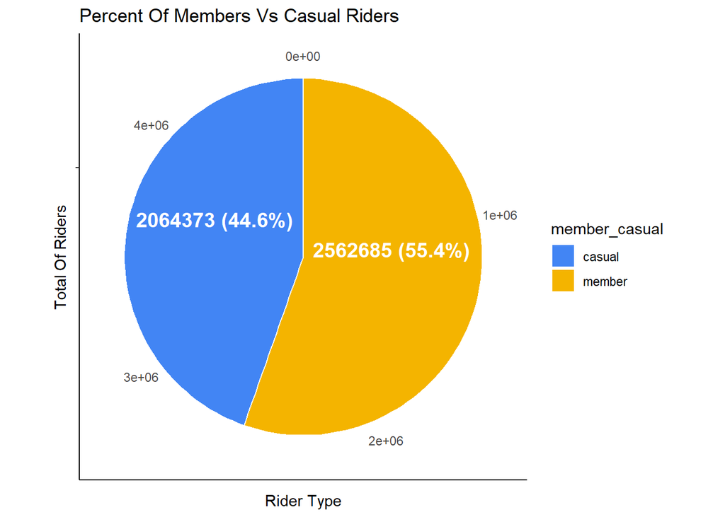

```r
mpgCount <- trip_dates%>%
  dplyr::count(member_casual)%>%
  dplyr::mutate(perc = n/sum(n) * 100)

pl <- ggplot (data = mpgCount, aes(x = "", y = n, fill = member_casual,))
pl <- pl + geom_col(width = 1, color = "white") + labs(x = "Total Of Riders", y = "Rider Type")
pl <- pl + geom_text(aes(x = "", y = n
                         , label = paste0(n, " (", round(perc,1),"%)")
                         , vjust = -1
), position = position_stack(vjust = 0.5), color="white", fontface = "bold", size=5)
pl <- pl + theme()
pl <- pl + theme_classic()
pl <- pl + labs(title ="Percent Of Members Vs Casual Riders")
pl <- pl + coord_polar("y", start=0)
pl <- pl + scale_fill_manual(values = c("#4285F4", "#F4B400"))
pl
```

As we can see in the graph, the subscribed members represent 55.4% of the total number of users, a slightly equal percentage.

### Convert trip legth to numeric and delete negative results

```r
trip_dates$ride_length <- as.numeric(as.character(trip_dates$ride_length))
trip_dates <- filter(trip_dates, ride_length > 0)
```

### Trip length average by member type

```r
summary(trip_dates$ride_length)
```

```
##     Min.  1st Qu.   Median     Mean  3rd Qu.     Max.
##     1.00     7.00    12.00    21.96    22.00 55944.00
```

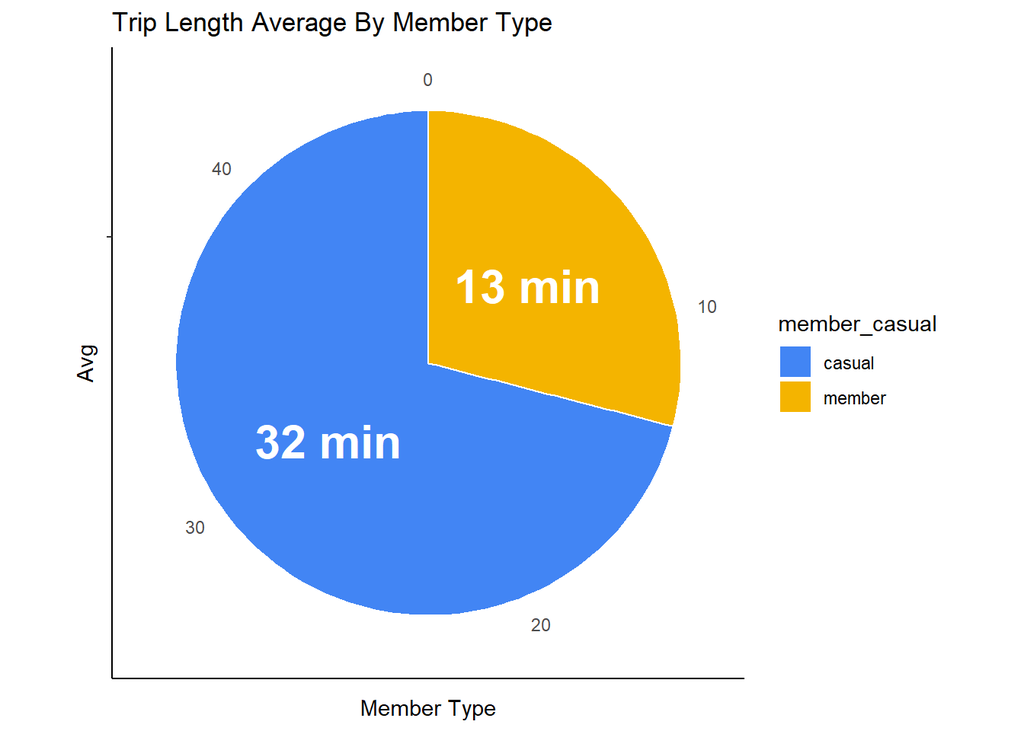

```r
trip_dates %>%
  group_by(member_casual) %>%
  summarise(avg_ride_lenth = mean(ride_length)) %>%
  ggplot(aes(x = "", y = avg_ride_lenth, fill = member_casual)) +
  geom_col(color = "white") + labs(title="Trip Length Average By Member Type", x = "Avg", y = "Member Type") +
  coord_polar("y", start=0) +
  scale_fill_manual(values = c("#4285F4", "#F4B400")) +
  theme_classic() +
  geom_text(aes(label = paste0(trunc(avg_ride_lenth, 0), " min")), position = position_stack(vjust = 0.5), color = "white", fontface = "bold", size=8)
```

### Type of bike per member

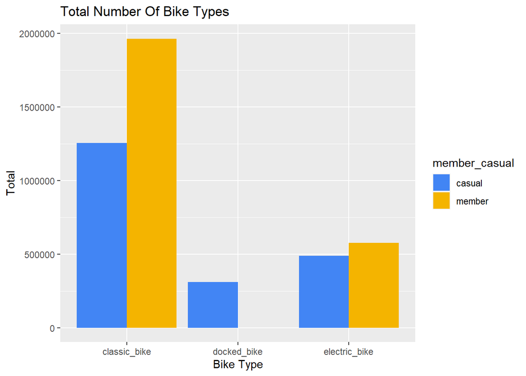

```r
trip_dates %>%
  group_by(member_casual, rideable_type) %>%
  summarise(number_of_bikes = n()) %>%
  arrange(rideable_type)%>%
  ggplot(aes(x = rideable_type, y = number_of_bikes, fill = member_casual)) +
  geom_col(position = "dodge") +
  labs(title="Total Number Of Bike Types", x = "Bike Type", y = "Total") +
  scale_fill_manual(values = c("#4285F4", "#F4B400"))
```

Classic bikes are the most used bikes for all riders and docked bikes the less used bikes being the casual rider the ones that only use this kind of bikes.

### Rides per month

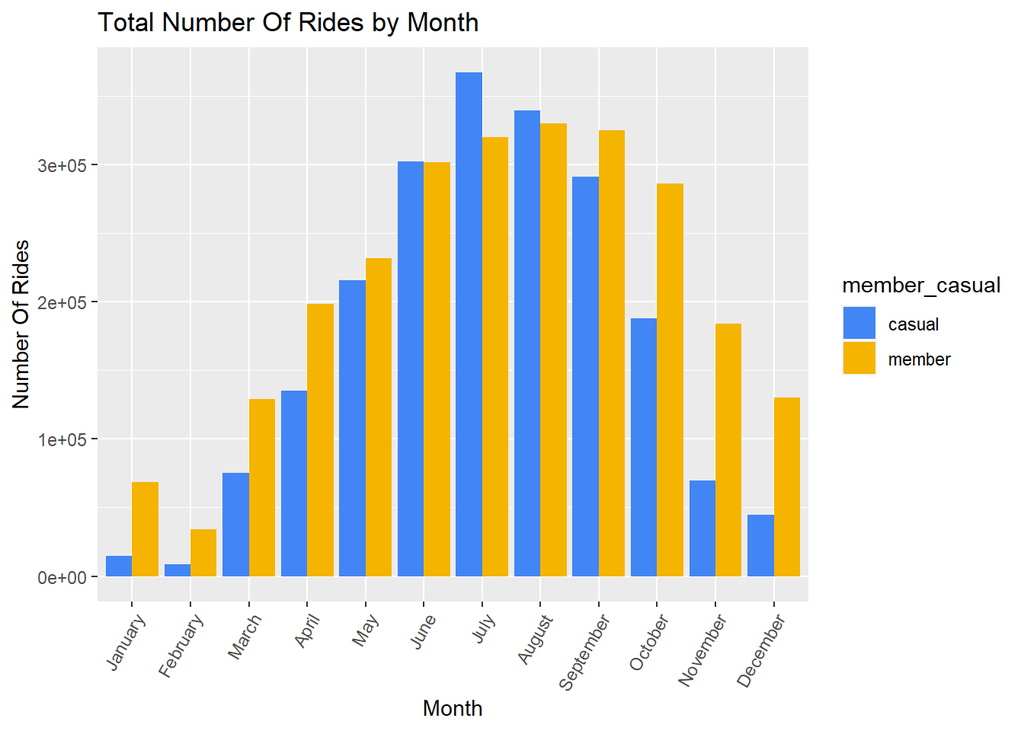

```r
trip_dates %>%
  group_by(member_casual, month) %>%
  summarise(number_of_rides = n()) %>%
  arrange(member_casual, month)%>%
  ggplot(aes(x = month, y = number_of_rides, fill = member_casual)) +
  geom_col(position = "dodge") + labs(title="Total Number Of Rides by Month", x = "Month", y = "Number Of Rides") +
  theme(axis.text.x = element_text(angle = 60, hjust = 1)) +
  scale_fill_manual(values = c("#4285F4", "#F4B400"))
```

June to September seems to be the busiest season for casual riders which coincides with the summer and vacation season reinforcing the theory that casual users may be tourists although members have a similar trend with June to October being the busiest.

### Rides per day

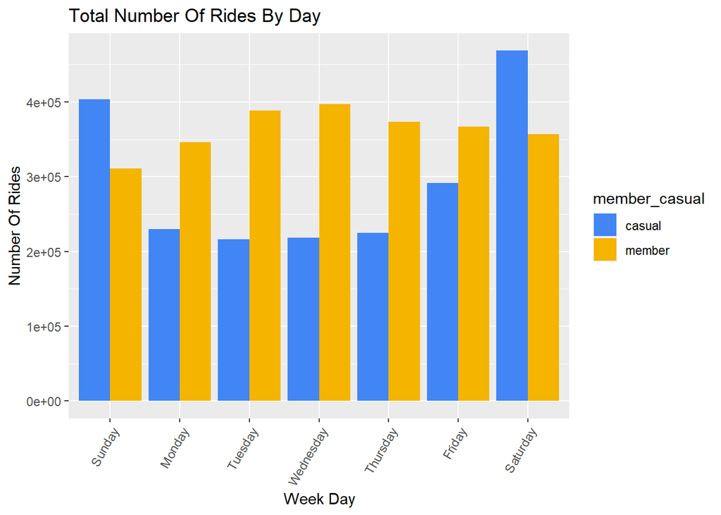

```r
trip_dates %>%
  group_by(member_casual, day_of_week) %>%
  summarise(number_of_rides = n()) %>%
  arrange(member_casual, day_of_week)%>%
  ggplot(aes(x = day_of_week, y = number_of_rides, fill = member_casual)) +
  geom_col(position = "dodge") + labs(title="Total Number Of Rides By Day", x = "Week Day", y = "Number Of Rides") +
  theme(axis.text.x = element_text(angle = 60, hjust = 1)) +
  scale_fill_manual(values = c("#4285F4", "#F4B400"))
```

Member users have a fairly balanced use throughout the week while casual users use the bikes more often on weekends.

### Rides per Hour

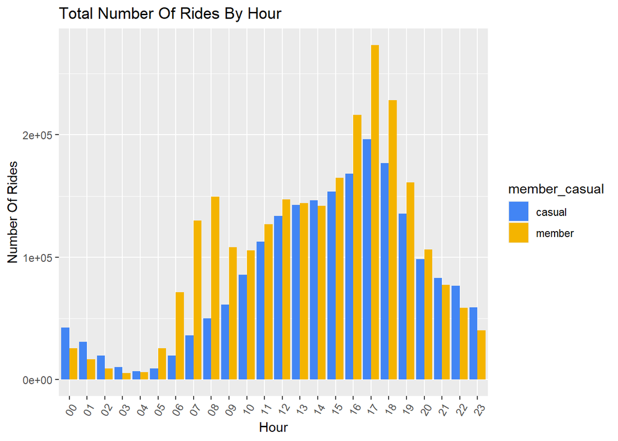

```r
trip_dates %>%
  group_by(member_casual, time) %>%
  summarise(number_of_rides = n()) %>%
  arrange(member_casual, time)%>%
  ggplot(aes(x = time, y = number_of_rides, fill = member_casual)) +
  geom_col(position = "dodge") + labs(title="Total Number Of Rides By Hour", x = "Hour", y = "Number Of Rides") +
  theme(axis.text.x = element_text(angle = 60, hjust = 1)) +
  scale_fill_manual(values = c("#4285F4", "#F4B400"))
```

### 10 most popular routes follow by casual riders.

[figure not shown]

Many of the casual users follow routes that start and end at the same station while the other significant observation is that there seems to be a common area where they pick up bikes in the 60611 neighborhood.

```r
library(knitr)
kable(top10_casual_routes[1:10, ], caption = "10 Most popular routes for casual users")
```

10 Most popular routes for casual users

| route | member_casual | start_lat | start_lng | end_lat | end_lng | count |
| --- | --- | --- | --- | --- | --- | --- |
| Streeter Dr & Grand Ave TO Streeter Dr & Grand Ave | casual | 41892278 | -87612043 | 41892278 | -87612043 | 10223 |
| Lake Shore Dr & Monroe St TO Lake Shore Dr & Monroe St | casual | 41880958 | -87616743 | 41880958 | -87616743 | 4195 |
| Michigan Ave & Oak St TO Michigan Ave & Oak St | casual | 4190096039 | -8762377664 | 4190096039 | -8762377664 | 3105 |
| Millennium Park TO Millennium Park | casual | 418810317 | -8762408432 | 418810317 | -8762408432 | 3020 |
| Theater on the Lake TO Theater on the Lake | casual | 41926277 | -87630834 | 41926277 | -87630834 | 2912 |
| DuSable Lake Shore Dr & Monroe St TO DuSable Lake Shore Dr & Monroe St | casual | 41880958 | -87616743 | 41880958 | -87616743 | 2719 |
| Montrose Harbor TO Montrose Harbor | casual | 41963982 | -87638181 | 41963982 | -87638181 | 2650 |
| Lake Shore Dr & Monroe St TO Streeter Dr & Grand Ave | casual | 41880958 | -87616743 | 41892278 | -87612043 | 2481 |
| Michigan Ave & 8th St TO Michigan Ave & 8th St | casual | 41872773 | -87623981 | 41872773 | -87623981 | 2452 |
| DuSable Lake Shore Dr & Monroe St TO Streeter Dr & Grand Ave | casual | 41880958 | -87616743 | 41892278 | -87612043 | 2388 |

### 10 most popular routes follow by member riders.

[figure not shown]

The members routes are more spread throughout the city, most likely, maybe in areas close to their place of work or residence.

```r
library(knitr)
kable(top10_member_routes[1:10, ], caption = "10 Most popular routes for member users")
```

10 Most popular routes for member users

[output not shown]

## Act

### Conclusion

In order to give a more accurate recommendation for a marketing campaign, further analysis and more data are needed to provide demographic specifications for the campaign and identify how many users are members or casuals and how often they use the bikes.